# WordPress Agents Exploratory Analysis- Part I- Univariate description - Refactored

Viviane Schneider

08/01/2019

**Type of Analysis:** Descriptive analysis - Univariate description

**Intention of Analysis**: 1- Understand how Core WordPress Community coproduce code. 2- Identify potential indicators for coherence analysis.

**General Question:** *Wich are the atributes of coproduction (colunms of dataframe or variables)?* **Specific Questions:** *Which type of developers groups exist in WC? It is possible to make some indicator from this data?*

**Source:** Data come from WordPress Report Trac System. URL Source **Dataframe:** [GitHub Repository](https://raw.githubusercontent.com/vivianesch/CoherenceAnalysisWordPress/master/TicketW.csv)

**Date collection:** 04/07/2019.

**1.GENERAL ANALYSIS**

```r
#READ DATA
library(readr)
library(dplyr)
```

```r
library(plotly)
library(tidyr)

TicketW <- read_csv('~/PhD Analysis/1. PhD escriptive exploratory analysis/TicketW.csv')
View(TicketW)
dim(TicketW) #dimension
```

```
## [1] 2333   16
```

```r
TicketW[1:5,]  #5 fist lines
```

```
## # A tibble: 5 x 16
##      id Summary Status Version Owner Type  Priority Milestone Component
##   <dbl> <chr>   <chr>  <lgl>   <chr> <chr> <chr>    <chr>     <chr>
## 1 24579 Add Dr~ new    NA      <NA>  enha~ high     Future R~ Upgrade/~
## 2 30361 Correc~ assig~ NA      pento task~ high     <NA>      General
## 3 32502 Cannot~ new    NA      <NA>  defe~ high     <NA>      Administ~
## 4 36441 Custom~ new    NA      <NA>  defe~ high     Future R~ Customize
## 5 40439 Save p~ assig~ NA      mike~ enha~ high     5.3       Media
## # ... with 7 more variables: Severity <chr>, Resolution <chr>,
## #   Created <chr>, Modified <chr>, Focuses <chr>, Reporter <chr>,
## #   Keywords <chr>
```

```r
summary(TicketW)
```

```
##        id          Summary             Status          Version
##  Min.   : 5235   Length:2333        Length:2333        Mode:logical
##  1st Qu.:34555   Class :character   Class :character   NA's:2333
##  Median :40511   Mode  :character   Mode  :character
##  Mean   :38029
##  3rd Qu.:44485
##  Max.   :47640
##     Owner               Type             Priority
##  Length:2333        Length:2333        Length:2333
##  Class :character   Class :character   Class :character
##  Mode  :character   Mode  :character   Mode  :character
##
##
##
##   Milestone          Component           Severity
##  Length:2333        Length:2333        Length:2333
##  Class :character   Class :character   Class :character
##  Mode  :character   Mode  :character   Mode  :character
##
##
##
##   Resolution          Created            Modified
##  Length:2333        Length:2333        Length:2333
##  Class :character   Class :character   Class :character
##  Mode  :character   Mode  :character   Mode  :character
##
##
##
##    Focuses            Reporter           Keywords
##  Length:2333        Length:2333        Length:2333
##  Class :character   Class :character   Class :character
##  Mode  :character   Mode  :character   Mode  :character
##
##
##
```

```r
glimpse(TicketW)
```

```
## Observations: 2,333
## Variables: 16
## $ id         <dbl> 24579, 30361, 32502, 36441, 40439, 41292, 41886, 41...
## $ Summary    <chr> "Add Drag'n'Drop UI to plugin and theme manual uplo...
## $ Status     <chr> "new", "assigned", "new", "new", "assigned", "reope...
## $ Version    <lgl> NA, NA, NA, NA, NA, NA, NA, NA, NA, NA, NA, NA, NA,...
## $ Owner      <chr> NA, "pento", NA, NA, "mikeschroder", "jnylen0", "me...
## $ Type       <chr> "enhancement", "task (blessed)", "defect (bug)", "d...
## $ Priority   <chr> "high", "high", "high", "high", "high", "high", "hi...
## $ Milestone  <chr> "Future Release", NA, NA, "Future Release", "5.3", ...
## $ Component  <chr> "Upgrade/Install", "General", "Administration", "Cu...
## $ Severity   <chr> "normal", "normal", "major", "normal", "normal", "n...
## $ Resolution <chr> NA, NA, NA, NA, NA, NA, NA, NA, NA, NA, NA, NA, NA,...
## $ Created    <chr> "06/14/2013 05:03:38 PM", "11/17/2014 12:10:55 PM",...
## $ Modified   <chr> "04/12/2019 11:04:54 AM", "06/04/2019 07:42:28 PM",...
## $ Focuses    <chr> NA, "ui, administration", NA, NA, "ui", NA, NA, NA,...
## $ Reporter   <chr> "tw2113", "pento", "ryan", "azaozz", "mikeschroder"...
## $ Keywords   <chr> "ui-feedback ux-feedback needs-patch shiny-updates"...
```

**Function unianalysis() - Transform vector into a data frame with frequency of levels and proportion**

```r
# Transform vector into a data frame with frequency of levels and proportion
.Unianalysis = function (x) {
    y <- as.data.frame(as.table(table(x)))
    y <- mutate(y, proportion = prop.table(y$Freq) *100)#Proportion
    y <- arrange(y, desc(y$Freq))
return(y)
}
```

**1.1 Variables related with members Analysis** **Goal:** Find which variables have hight variability, and find a line of cut, in order to use into Bivariate Analysis.

```r
# Var1
Status<-.Unianalysis(TicketW$Status)

#Var2
TType<-.Unianalysis(TicketW$Type)

#Var3
Priority<-.Unianalysis(TicketW$Priority)

#Var4
Milestone<-.Unianalysis(TicketW$Milestone)

#Var5
Component<-.Unianalysis(TicketW$Component)
Component = filter(Component, Freq>90) # Filter components with more than 100 tickets
sum(Component$Freq) #Total Tickets into most frequent components (more than 100 tickets)
```

```
## [1] 738
```

```r
#Var6
Severity<-.Unianalysis(TicketW$Severity)

#Var7
Focuses<-.Unianalysis(TicketW$Focuses)
Focuses = filter(Focuses, Freq>10) # Filter Focuses with more than 10 tickets
Focuses<-Focuses[order(Focuses$Freq, decreasing = TRUE),]
sum(Focuses$Freq) #Total Tickets into most frequent components (more than 100 tickets)
```

```
## [1] 832
```

```r
#Var8
Keywords<-.Unianalysis(TicketW$Keywords)
Keywords = filter(Keywords, Freq>8)
Keywords<-Keywords[order(Keywords$Freq, decreasing = TRUE),]
sum(Keywords$Freq)
```

```
## [1] 1082
```

**Functions for establish groups of active (GroupActive()), median (GroupMedian()), or less active (GroupAlien()) members:**

```r
#1. Filter Group of agents
.Grouping = function(x, less, more) {
        y = filter(x, Freq < less & Freq > more)
        x <- y[order(y$Freq, decreasing = TRUE),]
        return(x)
}
```

**1.2 Variable Members Analysis - Reporters:** Reporters are WordPress Community members who find and report a problem from WP Platform, into a Ticket.

**Goal:** Find type of report member groups (actives, medians, and aliens), and find a line of cut, in order to use into Bivariate Analysis.

```r
#Find Groups and quantity of people for each group

Reporter<-.Unianalysis(TicketW$Reporter)
totalReporter<-nrow(Reporter)

ActiveReporters<-.Grouping(Reporter, 1000, 10)
totalAR<-nrow(ActiveReporters)

MedianReporters<-.Grouping(Reporter, 10, 4)
totalMR<-nrow(MedianReporters)

LessReporters<-.Grouping(Reporter, 4, 0)
totalLR<-nrow(LessReporters)
```

**1.3 Variable Member Analysis - Owners:** Owners are WordPress Community members who pick up a ticket from WP Platform (sended by a reporter) in order to solve it.

**Goal:** Find type of owner member groups (actives, medians, and aliens), and find a line of cut, in order to use into Bivariate Analysis.

```r
Owner <-.Unianalysis(TicketW$Owner)
totalOwner <-nrow(Owner)

#Find Groups and quantity of people for each group

ActiveOwner <-.Grouping(Owner, 1000, 10)
totalAO <-nrow(ActiveOwner)

MedianOwner <-.Grouping(Owner, 10, 4)
totalMO <-nrow(MedianOwner)

LessOwner <-.Grouping(Owner, 4, 0)
totalLO <-nrow(LessOwner)
```

**1.4 Sum of groups by Reporters and Owners:**

```r
#Total members per Reporter
MembersTotal<-c(totalAR,totalMR,totalLR)
CoreGroup<-rbind("Active Reporters","Median Reporters","Alien Reporters")
WPCGroupR<-data.frame(CoreGroup,MembersTotal)

#Total members per Owner
MembersTotal<-c(totalAO,totalMO,totalLO)
CoreGroup<-rbind("Active Owners","Median Owners","Alien Owners")
WPCGroupO<-data.frame(CoreGroup,MembersTotal)

#Total members per every groups
MembersTotal<- c(totalOwner,totalReporter)
CoreGroup <- rbind("Owners","Reporters")
WPCGroups <- data.frame(CoreGroup,MembersTotal)
```

**2. DESCRIPTION ANALYSIS REPORT :**

```r
library(plotrix)
library(plotly)
library(ggplot2)
library(wordcloud)
#Graphic Function
#Fun Plot
.Plot_FunPlot = function(x,y) {
  fan.plot(x$Freq,
           max.span=pi,
           labels=paste(x$x, x$Freq, sep=": "),
            main=y,ticks=360)
}
#Word Plot
.Plot_word = function(x, num1, num2) {
     wordcloud(words = x$x, freq = x$Freq, min.freq = num1,
              max.words=num2, random.order=FALSE, rot.per=0.35,
              colors=brewer.pal(8, "Dark2"))
}

Status#Var1
```

```
##           x Freq proportion
## 1       new 1844  79.039863
## 2  assigned  215   9.215602
## 3  reopened  116   4.972139
## 4 reviewing  105   4.500643
## 5  accepted   53   2.271753
```

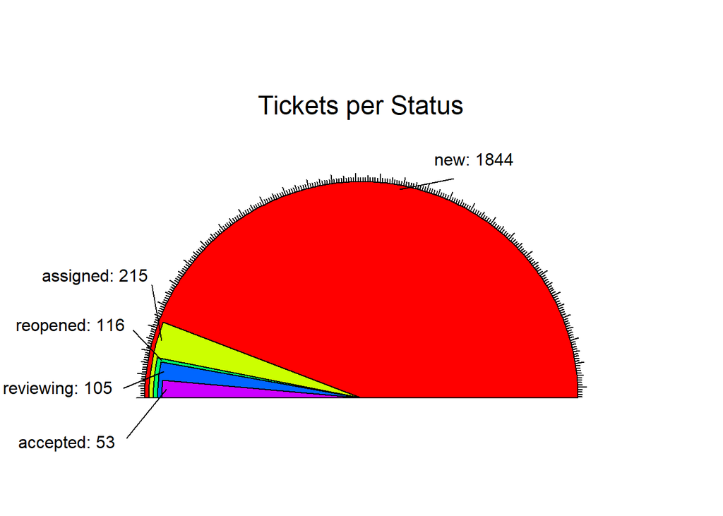

```r
#Graphics
.Plot_FunPlot(Status, "Tickets per Status")
```

```r
TType# Var2
```

```
##                 x Freq proportion
## 1     enhancement 1109  47.535362
## 2    defect (bug) 1012  43.377625
## 3 feature request  168   7.201029
## 4  task (blessed)   44   1.885984
```

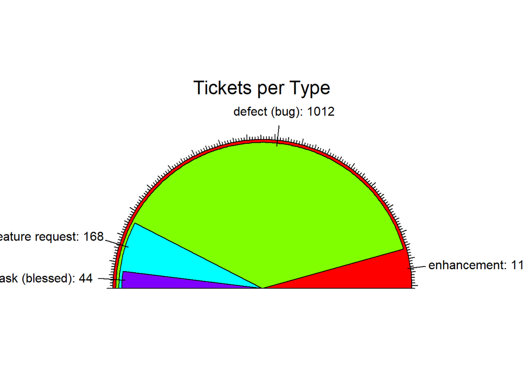

```r
#Graphics
.Plot_FunPlot(TType, "Tickets per Type")
```

```r
Priority# Var3
```

```
##        x Freq proportion
## 1 normal 2265 97.0852979
## 2    low   49  2.1003000
## 3   high   12  0.5143592
## 4 lowest    7  0.3000429
```

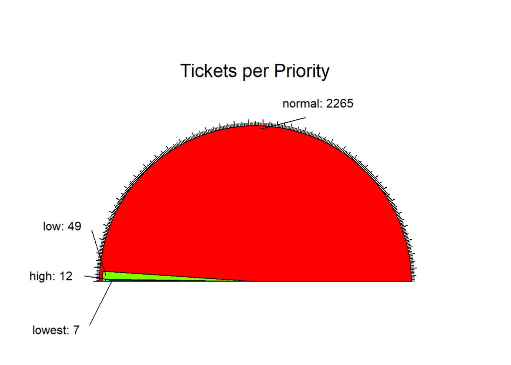

```r
#Graphics
.Plot_FunPlot(Priority, "Tickets per Priority")
```

```r
Milestone#Var4
```

```
##                 x Freq  proportion
## 1 Awaiting Review 1104 60.19629226
## 2  Future Release  544 29.66194111
## 3             5.3  172  9.37840785
## 4   WordPress.org   13  0.70883315
## 5           5.2.3    1  0.05452563
```

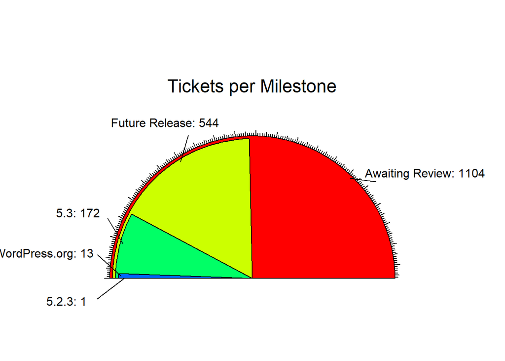

```r
#Graphics
.Plot_FunPlot(Milestone, "Tickets per Milestone")
```

```r
Component#Var5
```

```
##                   x Freq proportion
## 1           General  205   8.786970
## 2             Media  166   7.115302
## 3    Administration  162   6.943849
## 4 Posts, Post Types  114   4.886412
## 5             Users   91   3.900557
```

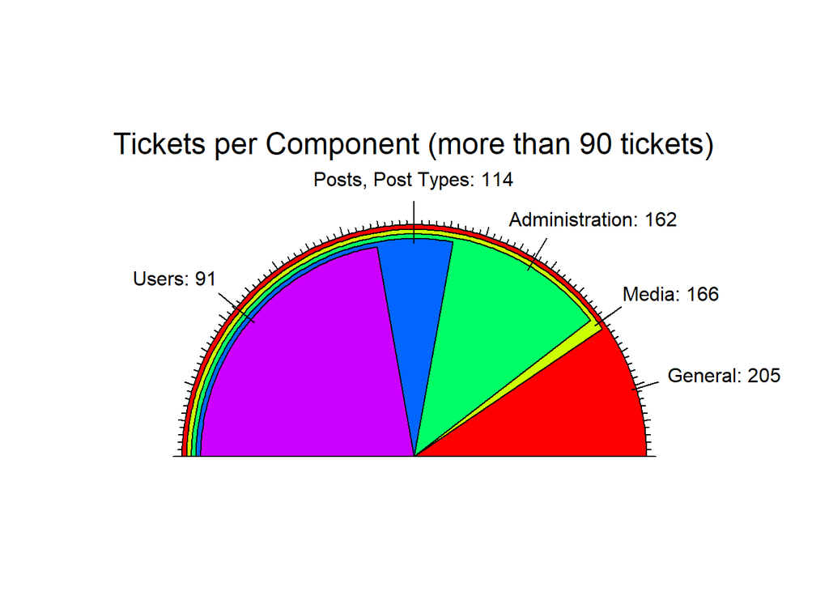

```r
#Graphic
.Plot_FunPlot(Component, "Tickets per Component (more than 90 tickets)")
```

```r
Severity #Var6
```

```
##          x Freq  proportion
## 1   normal 2186 93.69909987
## 2    minor   91  3.90055722
## 3    major   27  1.15730819
## 4  trivial   19  0.81440206
## 5 critical    9  0.38576940
## 6  blocker    1  0.04286327
```

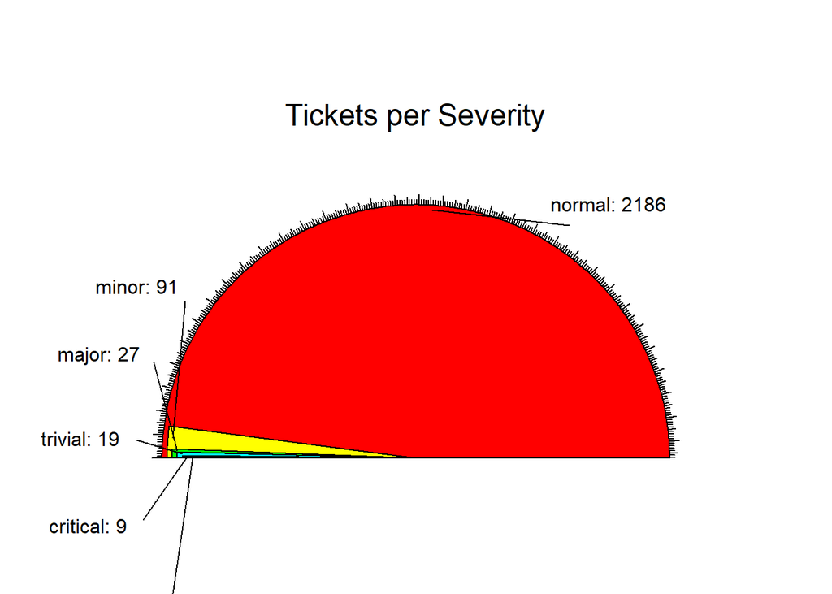

```r
#Graphics
.Plot_FunPlot(Severity, "Tickets per Severity")
```

```r
Focuses#Var7
```

```
##                     x Freq proportion
## 1      administration  192  19.512195
## 2                  ui  103  10.467480
## 3  ui, administration  101  10.264228
## 4           multisite   95   9.654472
## 5                docs   58   5.894309
## 6         performance   55   5.589431
## 7   ui, accessibility   51   5.182927
## 8          javascript   49   4.979675
## 9            template   48   4.878049
## 10           rest-api   30   3.048780
## 11   coding-standards   27   2.743902
## 12      accessibility   23   2.337398
```

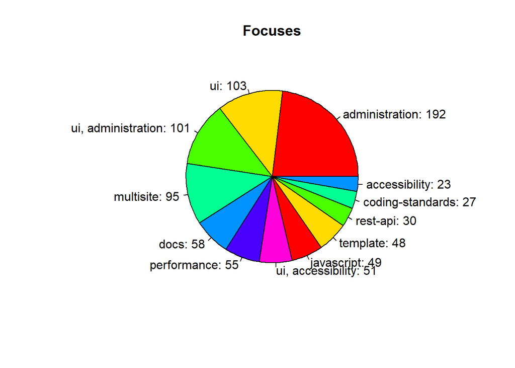

```r
#Graphics
pie(Focuses$Freq, main="Focuses", label = paste(Focuses$x, sep=": ", Focuses$Freq), col = rainbow(7))
```

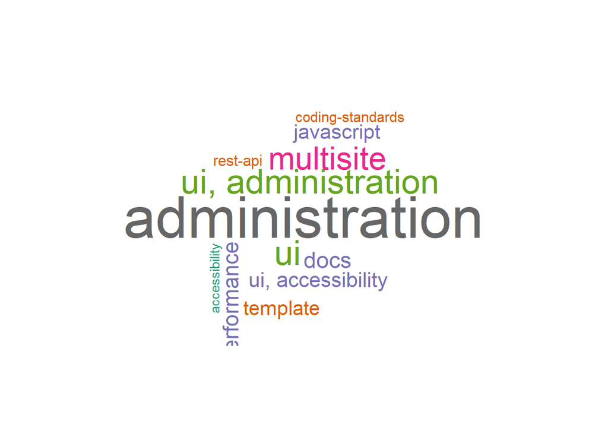

```r
.Plot_word(Focuses, 20, 200)
```

```r
Keywords#Var8
```

```
##                               x Freq proportion
## 1                   needs-patch  266 15.2873563
## 2                     has-patch  246 14.1379310
## 3             reporter-feedback   57  3.2758621
## 4                   2nd-opinion   55  3.1609195
## 5       has-patch needs-refresh   47  2.7011494
## 6  needs-patch needs-unit-tests   46  2.6436782
## 7       has-patch needs-testing   44  2.5287356
## 8        has-patch dev-feedback   40  2.2988506
## 9      has-patch has-unit-tests   31  1.7816092
## 10        has-patch 2nd-opinion   29  1.6666667
## 11                 dev-feedback   28  1.6091954
## 12                        close   27  1.5517241
## 13   has-patch needs-unit-tests   24  1.3793103
## 14      needs-patch 2nd-opinion   19  1.0919540
## 15     good-first-bug has-patch   18  1.0344828
## 16  has-patch reporter-feedback   17  0.9770115
## 17              has-screenshots   15  0.8620690
## 18    has-screenshots has-patch   15  0.8620690
## 19    has-patch has-screenshots   14  0.8045977
## 20     dev-feedback needs-patch   13  0.7471264
## 21     needs-patch dev-feedback   13  0.7471264
## 22      2nd-opinion needs-patch    9  0.5172414
## 23       dev-feedback has-patch    9  0.5172414
```

[figure not shown]

```r
#Graphics
pie(Keywords$Freq, main="Focuses", label = paste(Keywords$x, sep=": ", Keywords$Freq), col = rainbow(7))
```

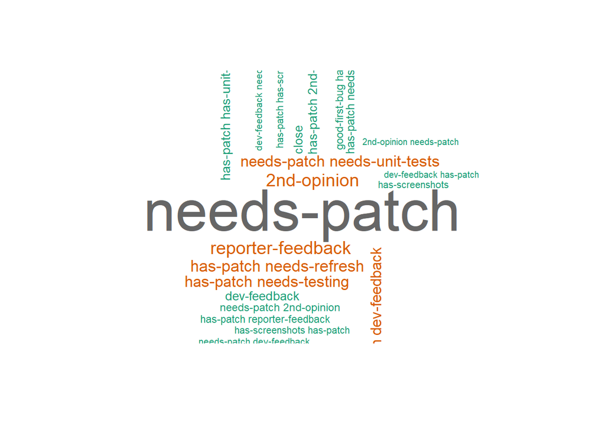

```r
.Plot_word(Keywords, 4, 300)
```

**2.2 Reporter Members Analysis Report** The groups of Reporters:

```r
ActiveReporters #Ranking the most active reporters
```

```
##                   x Freq proportion
## 1       johnbillion   72  3.0861552
## 2           afercia   53  2.2717531
## 3   johnjamesjacoby   47  2.0145735
## 4  sebastian.pisula   43  1.8431204
## 5          flixos90   42  1.8002572
## 6   danielbachhuber   39  1.6716674
## 7        karmatosed   33  1.4144878
## 8            rmccue   27  1.1573082
## 9  subrataemfluence   25  1.0715817
## 10      westonruter   24  1.0287184
## 11            nacin   23  0.9858551
## 12          desrosj   22  0.9429919
## 13  garrett-eclipse   22  0.9429919
## 14           pbiron   22  0.9429919
```

[output cut: 20 more lines]

```r
MedianReporters #Ranking the Median active reporters
```

```
##                 x Freq proportion
## 1       ericlewis    8  0.3429061
## 2         iandunn    8  0.3429061
## 3      jeremyfelt    8  0.3429061
## 4     joostdevalk    8  0.3429061
## 5          kjellr    8  0.3429061
## 6          netweb    8  0.3429061
## 7       pavelevap    8  0.3429061
## 8      programmin    8  0.3429061
## 9       alexvorn2    7  0.3000429
## 10           andy    7  0.3000429
## 11         eclare    7  0.3000429
## 12    Frank Klein    7  0.3000429
## 13       jdgrimes    7  0.3000429
## 14        pbearne    7  0.3000429
```

[output cut: 22 more lines]

```r
LessReporters[c(1:30),c(1:2)] #Ranking the 30 less active Reporters
```

```
##                    x Freq
## 1           allendav    3
## 2              arena    3
## 3       chetan200891    3
## 4  chinteshprajapati    3
## 5           danieltj    3
## 6  Denis-de-Bernardy    3
## 7          diddledan    3
## 8            dimadin    3
## 9         dotancohen    3
## 10             duck_    3
## 11           fliespl    3
## 12             GaryJ    3
## 13       hlashbrooke    3
## 14          ishitaka    3
```

[output cut: 16 more lines]

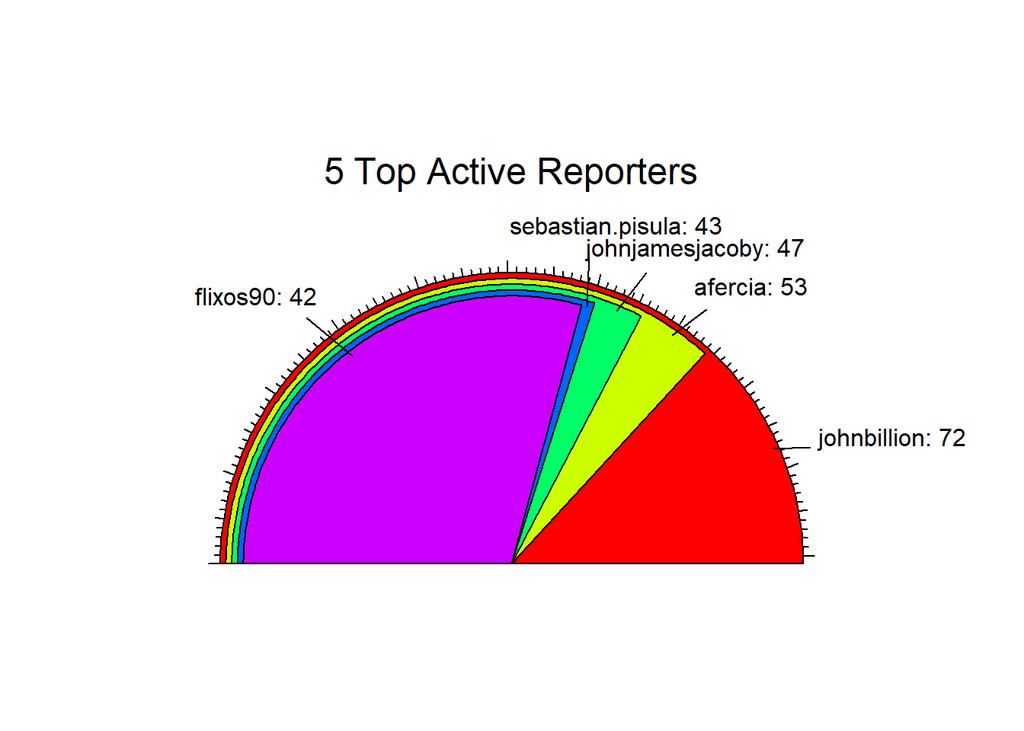

```r
#Grafic of Top 5 active Reporters
.Plot_FunPlot(ActiveReporters[1:5, 1:2], "5 Top Active Reporters")
```

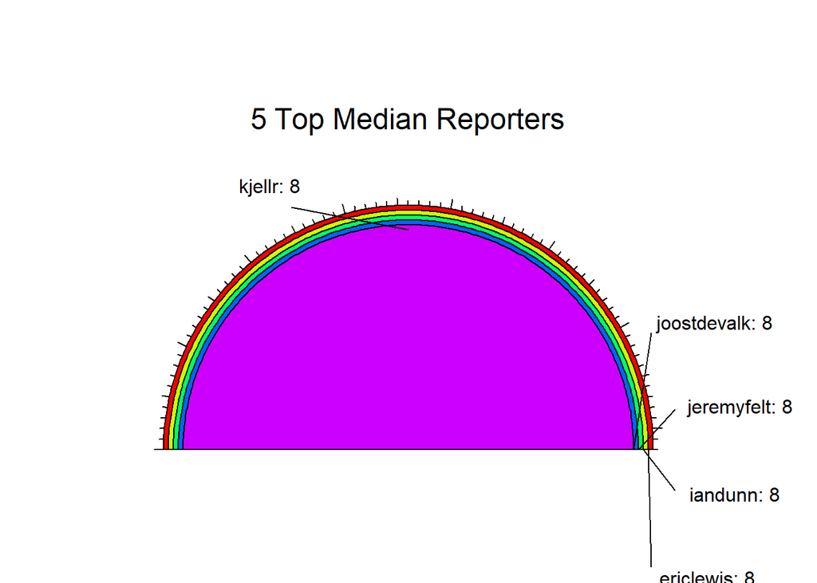

```r
.Plot_FunPlot(MedianReporters[1:5, 1:2], "5 Top Median Reporters")
```

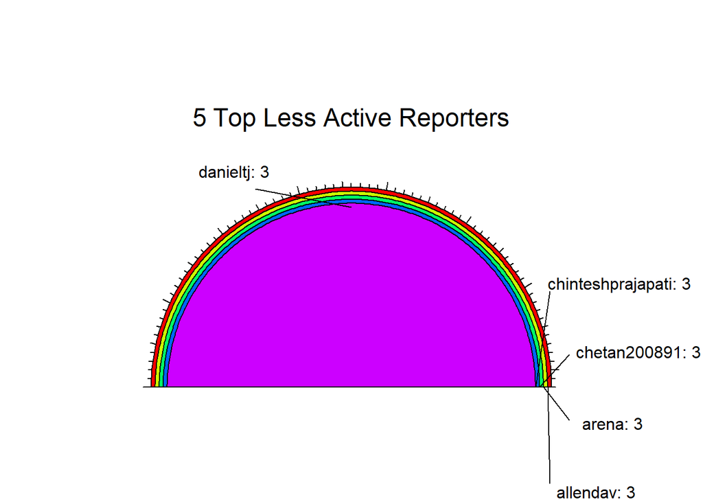

```r
.Plot_FunPlot(LessReporters[1:5, 1:2], "5 Top Less Active Reporters")
```

**2.3 Owner Members Analysis Report:** The groups of Owners:

```r
ActiveOwner#Ranking the most active Owners
```

```
##                 x Freq proportion
## 1  SergeyBiryukov   67  18.662953
## 2        audrasjb   18   5.013928
## 3     johnbillion   16   4.456825
## 4       chriscct7   15   4.178273
## 5       joemcgill   14   3.899721
## 6 adamsilverstein   13   3.621170
```

```r
MedianOwner#Ranking the Median Owners
```

```
##                 x Freq proportion
## 1         desrosj    9   2.506964
## 2           nacin    8   2.228412
## 3         afercia    7   1.949861
## 4    boonebgorges    7   1.949861
## 5           pento    7   1.949861
## 6          azaozz    6   1.671309
## 7        flixos90    6   1.671309
## 8      jeremyfelt    6   1.671309
## 9          rmccue    6   1.671309
## 10          westi    6   1.671309
## 11    westonruter    5   1.392758
## 12 wonderboymusic    5   1.392758
```

```r
LessOwner[c(1:30),c(1:2)]#Ranking the 30 less active Owners
```

```
##                    x Freq
## 1               dd32    3
## 2           joehoyle    3
## 3           tz-media    3
## 4               xkon    3
## 5      davidakennedy    2
## 6           dswebsme    2
## 7          ericlewis    2
## 8    garrett-eclipse    2
## 9        ianbelanger    2
## 10           iseulde    2
## 11           jnylen0    2
## 12       joostdevalk    2
## 13           kapeels    2
## 14       markjaquith    2
```

[output cut: 16 more lines]

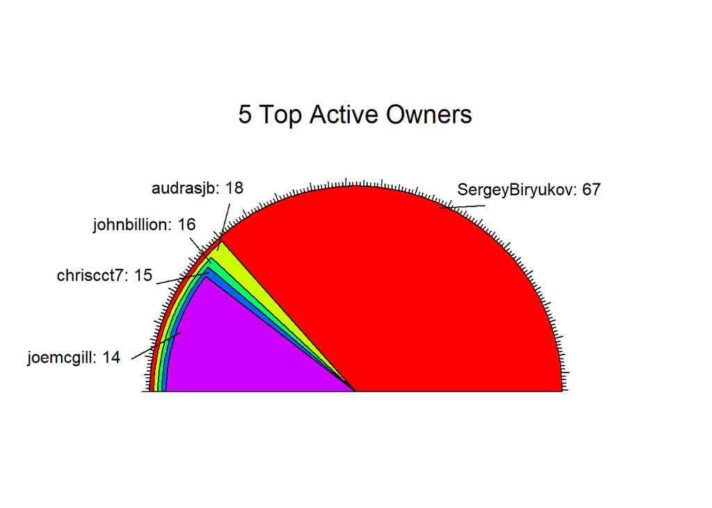

```r
#Grafic of Owners

#Grafic of Top 5 active Owners
.Plot_FunPlot(ActiveOwner[1:5, 1:2], "5 Top Active Owners")
```

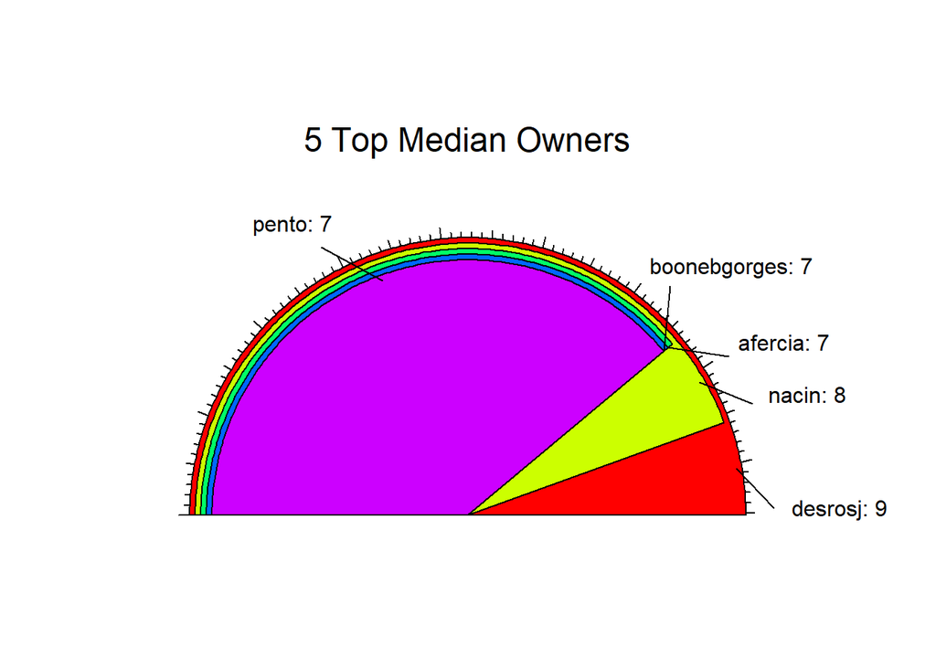

```r
.Plot_FunPlot(MedianOwner[1:5, 1:2], "5 Top Median Owners")
```

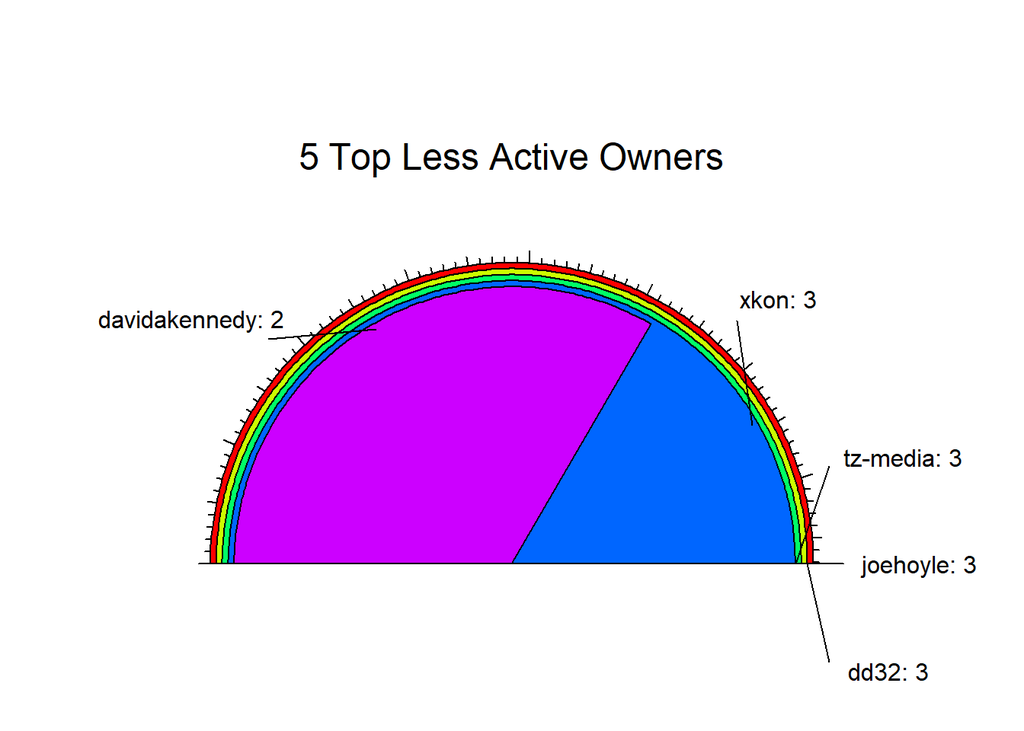

```r
.Plot_FunPlot(LessOwner[1:5, 1:2], "5 Top Less Active Owners")
```

**2.4 Comparation of groups by Reporters and Owners:**

```r
WPCGroups
```

```
##   CoreGroup MembersTotal
## 1    Owners          116
## 2 Reporters         1028
```

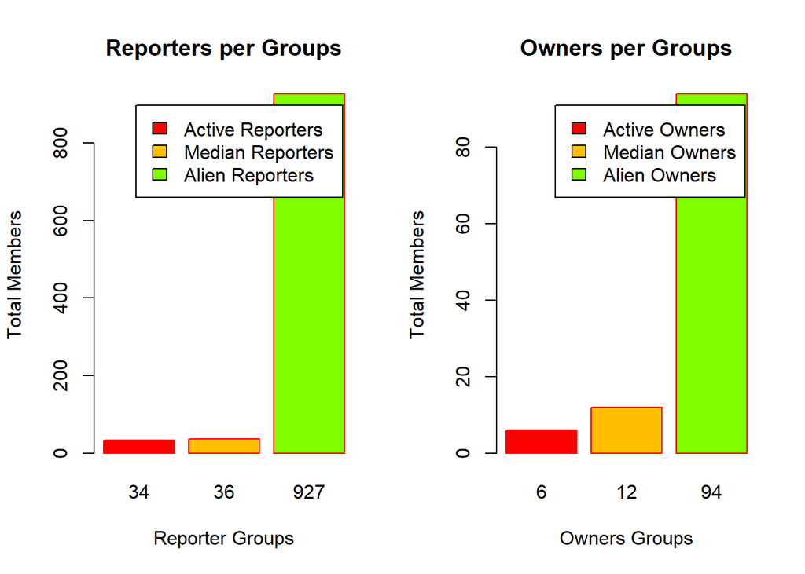

```r
par(mfrow=c(1,2))
barplot(WPCGroupR$MembersTotal,
        names.arg=WPCGroupR$MembersTotal,
        xlab="Reporter Groups",
        ylab="Total Members",
        legend=WPCGroupR$CoreGroup,
        col=rainbow(8),
        main="Reporters per Groups",border="red")

barplot(WPCGroupO$MembersTotal,
        names.arg=WPCGroupO$MembersTotal,
        xlab="Owners Groups",
        ylab="Total Members",
        legend=WPCGroupO$CoreGroup,
        col=rainbow(8),
        main="Owners per Groups",border="red")
```

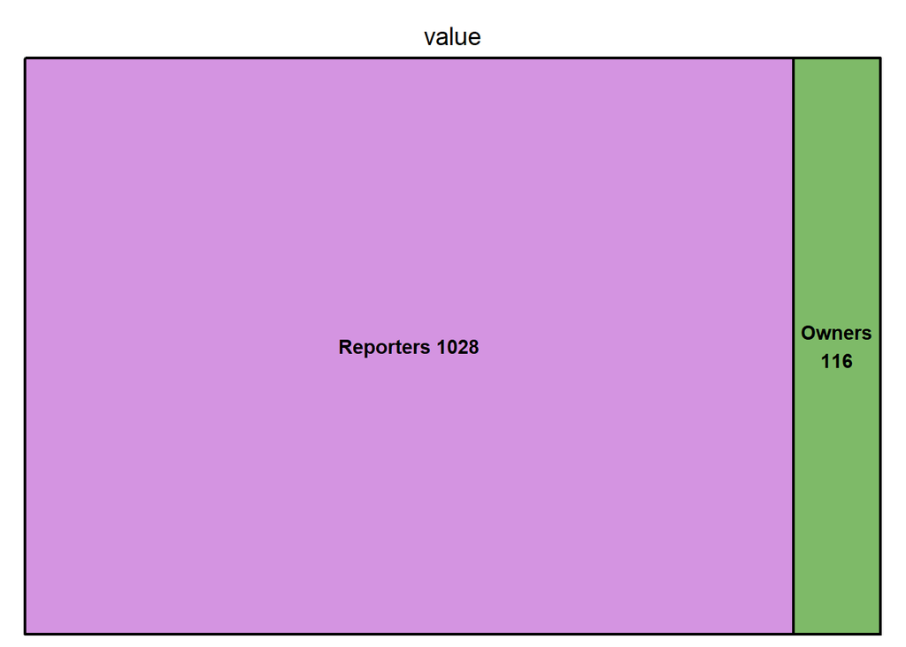

```r
# Load ggplot2
library(ggplot2)
library(dplyr)
# library
library(treemap)

# treemap
.Tree_Map = function(x){
  group <- paste(x$CoreGroup, x$MembersTotal)
  value <- x$MembersTotal
  data <- data.frame(group,value)
     treemap(data,
            index="group",
            vSize="value",
            type="index")
}


par(mfrow=c(1,3))
.Tree_Map(WPCGroups) #Total Owner and Reporters
```

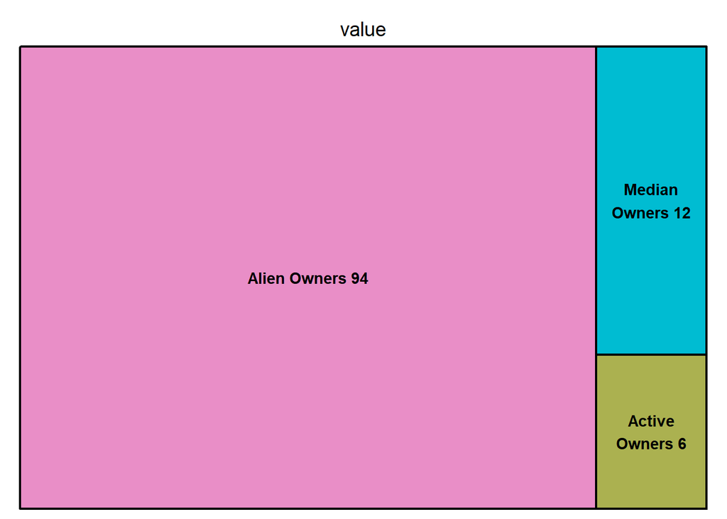

```r
.Tree_Map(WPCGroupO) #Groups of Owners
```

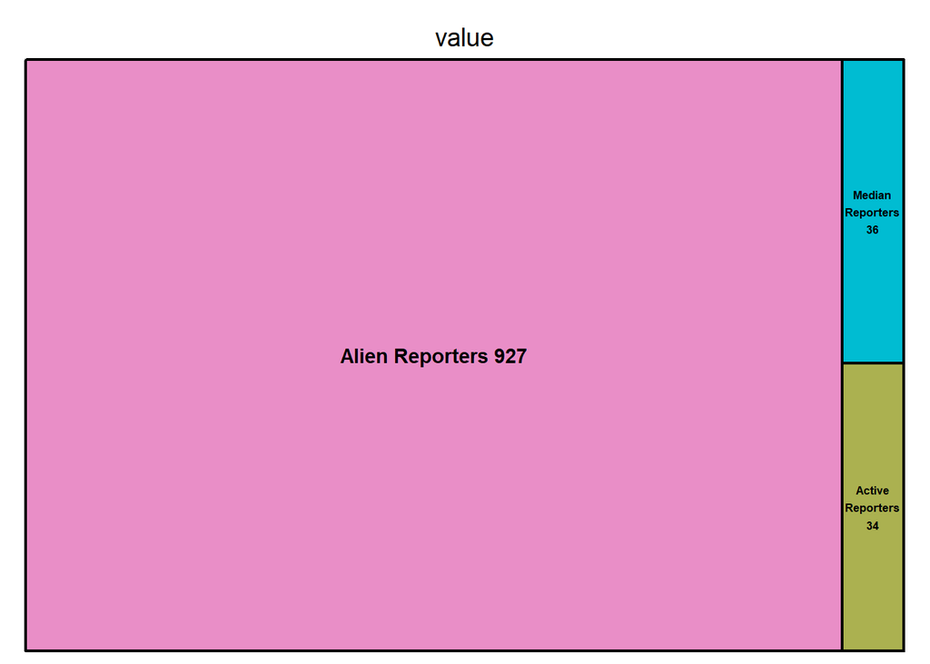

```r
.Tree_Map(WPCGroupR) #Groups of Reporters
```

**3. POTENTIAL INDICATORS:**

- The “Sense of Unity” Dimension indicator:
  - Mode_Agents_Rules: In a scale from O to 1, this indicator represents the principals rules the WP members play in the community: active, median and alien. This unformal rules are observed into formal groups: owners and reporters. The Hypothesis is that the Reporters Group and the Owners Group have a similar distribution of tickets per its the respectives sub groups(active, median, and alien).

Hypothesis: $PropMo = PropMR$

Means: percentual of tickets into any subgroups into Owner Groups are similar thand percentual of tickets into any subgroups into Reporter Groups

Hypothesis test:

```r
PropMR<-prop.table(WPCGroupR$MembersTotal)# Proportion
PropMO<-prop.table(WPCGroupO$MembersTotal)# Proportion

similarityOR<-ifelse(PropMO>PropMR,1-(PropMO-PropMR),1-(PropMR-PropMO))
similarityOR<-mean(similarityOR)
similarityOR
```

```
## [1] 0.9396642
```

Thus, Mode_Agents_Rules indicator is = similarityOR.

**4. FINAL CONCLUSIONS:**

Despite the most of tickets have no owner, there are not so many urgent issues. Around 93% of tickets are classified as Severity “normal”, and 97% are classified as Priority “Normal”.

According with this description, are recommended analyse in a bivariable description the folow variables:

- Variables for setup a referential of the community (The “Referentiality” Dimension): Documentation of values, general view and beiefs of community
- Variables for analyse the “Prescritivity” dimension: Analyse the community referential with “Focuses” Variable, in order to verify if the members produced what they stablished into referential.
- Variables for analyse the “Sense of Unity” dimension: “Keywords” Variable, in order to verify the correlation with groups
- Variables for analyse the the “Receptivity” dimension: Groups of members, correlation between groups and Status, Type, Milestone variables